# Simple Linear Regression

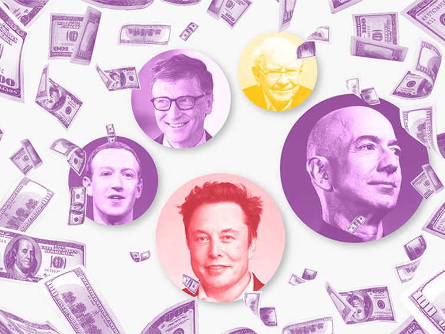

```r
# Load libraries
library(tidyverse)
library(pander)
library(ggplot2)
library(dplyr)

# Read the data into R
billionaires <- read.csv("Billionaires.csv", header=TRUE)

# Filter out NA values in the "Children" and "NetWorth" columns
billionaires <- billionaires %>%
  drop_na(Age, Real.Time.Net.Worth) %>%
  rename(NetWorth = Real.Time.Net.Worth)

# Convert Net Worth column to numeric
billionaires$NetWorth <- ifelse(grepl("B", billionaires$NetWorth),
                                as.numeric(gsub("\\$|B", "", billionaires$NetWorth)) * 1e9,
                                as.numeric(gsub("\\$|M", "", billionaires$NetWorth)) * 1e6)
```

## Introduction

In this case study, I will be examining the relationship between age and net worth in a dataset of billionaires. The analysis involves fitting a simple linear regression model to the data and examining the resulting statistical measures. The insights gained from the analysis can inform our understanding of how age impacts net worth in this particular population.

## Hypothesis

I think that there may be a connection between **age** and **net worth** of billionaires, indicating that the older they are, the higher their net worth.

To explore this, I’ll create a linear regression model with net worth as the dependent variable and age as the independent variable.

$$H_0: \text{Age is not a predictor of net worth among billionaires}$$

$$H_a: \text{Age is a significant predictor of net worth among
billionaires}$$

I will use a simple linear regression model to determine the linear relationship between age and net worth. The formula for the model is:

$$\underbrace{Y_i}_\text{Net Worth} = \beta_0 + \beta_1
\underbrace{X_i}_\text{Age} + \epsilon_i \quad \text{where} \ \epsilon_i
\sim N(0, \sigma^2)$$